# Coursera Practical Machine Learning Course Project - Exercise Prediction

Aswin Andrianto

September 23, 2017

# 1) Original Study and Data Source

Source of data from the following study:

*Velloso, E.; Bulling, A.; Gellersen, H.; Ugulino, W.; Fuks, H. Qualitative Activity Recognition of Weight Lifting Exercises. Proceedings of 4th International Conference in Cooperation with SIGCHI (Augmented Human ’13) . Stuttgart, Germany: ACM SIGCHI, 2013*

# 2) Overview

The goal of this project is to “predict the manner in which they did the exercise.”

In the aforementioned study, six participants participated in a dumbell lifting exercise five different ways. They are as follows: * (Class A) correct technique * (Class B) throwing the elbows to the front * (Class C) lifting the dumbbell only halfway * (Class D) lowering the dumbbell only halfway * (Class E) throwing the hips to the front

Class A corresponds to the correct execution of the exercise, while the other 4 classes correspond to common mistakes

# 3) Data Preparation

## a. Load Library

```r
#Load libraries
library("caret")
```

## b. Load Data, Clean Data, and Check Dimension

```r
#Download the data
if(!file.exists("pml-training.csv")){download.file("https://d396qusza40orc.cloudfront.net/predmachlearn/pml-training.csv", destfile = "pml-training.csv")}

if(!file.exists("pml-testing.csv")){download.file("https://d396qusza40orc.cloudfront.net/predmachlearn/pml-testing.csv", destfile = "pml-testing.csv")}


#Read the training data and replace empty values by NA
trainingDataSet<- read.csv("pml-training.csv", sep=",", header=TRUE, na.strings = c("NA","",'#DIV/0!'))
testingDataSet<- read.csv("pml-testing.csv", sep=",", header=TRUE, na.strings = c("NA","",'#DIV/0!'))
#remove columns containing NA
trainingDataSet <- trainingDataSet[,(colSums(is.na(trainingDataSet)) == 0)]
testingDataSet <- testingDataSet[,(colSums(is.na(testingDataSet)) == 0)]
#check training data dimension
dim(trainingDataSet)
```

```
## [1] 19622    60
```

```r
#check testing data dimension
dim(testingDataSet)
```

```
## [1] 20 60
```

## c. Pre-Process Data

```r
numericalsIdx <- which(lapply(trainingDataSet, class) %in% "numeric")

preprocessModel <-preProcess(trainingDataSet[,numericalsIdx],method=c('knnImpute', 'center', 'scale'))
pre_trainingDataSet <- predict(preprocessModel, trainingDataSet[,numericalsIdx])
pre_trainingDataSet$classe <- trainingDataSet$classe

pre_testingDataSet <-predict(preprocessModel,testingDataSet[,numericalsIdx])
```

## d. Remove non-significant cariables (near-zero)

```r
nzv <- nearZeroVar(pre_trainingDataSet,saveMetrics=TRUE)
pre_trainingDataSet <- pre_trainingDataSet[,nzv$nzv==FALSE]

nzv <- nearZeroVar(pre_testingDataSet,saveMetrics=TRUE)
pre_testingDataSet <- pre_testingDataSet[,nzv$nzv==FALSE]
```

## e. Partition Validation Set

```r
set.seed(151088)
idxTrain<- createDataPartition(pre_trainingDataSet$classe, p=3/4, list=FALSE)
training<- pre_trainingDataSet[idxTrain, ]
validation <- pre_trainingDataSet[-idxTrain, ]
dim(training) ; dim(validation)
```

```
## [1] 14718    28
```

```
## [1] 4904   28
```

# 4) Train Model

```r
library(randomForest)
modFitrf <- train(classe ~., method="rf", data=training, trControl=trainControl(method='cv'), number=5, allowParallel=TRUE, importance=TRUE )
modFitrf
```

```
## Random Forest
##
## 14718 samples
##    27 predictor
##     5 classes: 'A', 'B', 'C', 'D', 'E'
##
## No pre-processing
## Resampling: Cross-Validated (10 fold)
## Summary of sample sizes: 13246, 13245, 13247, 13246, 13247, 13245, ...
## Resampling results across tuning parameters:
##
##   mtry  Accuracy   Kappa
##    2    0.9926616  0.9907170
##   14    0.9921180  0.9900302
##   27    0.9888574  0.9859054
##
## Accuracy was used to select the optimal model using  the largest value.
## The final value used for the model was mtry = 2.
```

## a. Plotting the importance of each variable

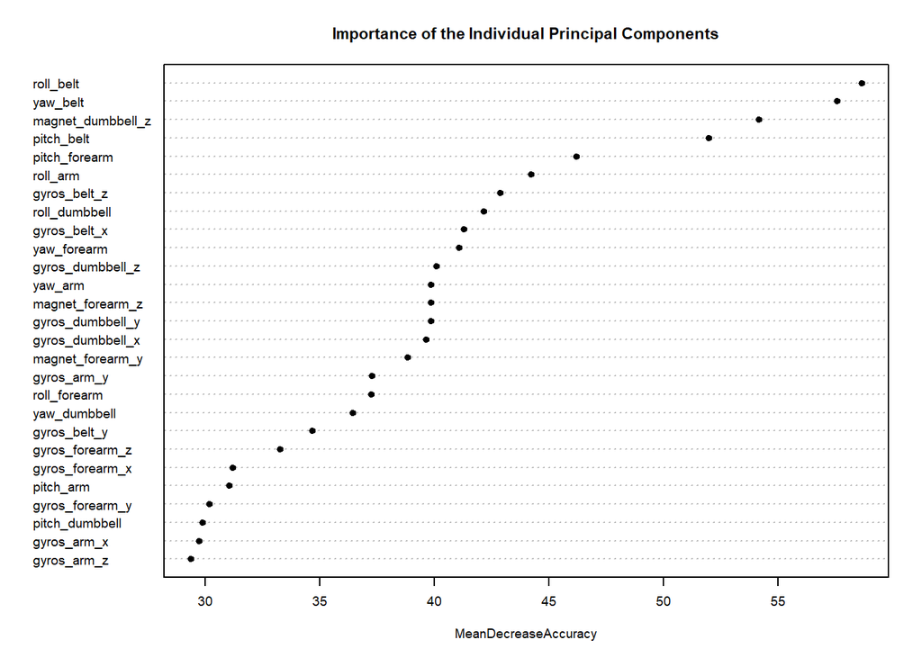

```r
varImpPlot(modFitrf$finalModel, sort = TRUE, type = 1, pch = 19, col = 1, cex = 0.6, main = "Importance of the Individual Principal Components")
```

The plot shows the importance of each component from most important to least important

## b. Cross Validation

```r
predValidRF <- predict(modFitrf, validation)
confus <- confusionMatrix(validation$classe, predValidRF)
confus$table
```

```
##           Reference
## Prediction    A    B    C    D    E
##          A 1394    1    0    0    0
##          B    8  937    4    0    0
##          C    0    3  849    3    0
##          D    0    0    2  799    3
##          E    0    0    0    0  901
```

Based on the above testing, almost all of the variables fit this model.

Check accuracy

```r
accur <- postResample(validation$classe, predValidRF)
modAccuracy <- accur[[1]]
modAccuracy
```

```
## [1] 0.995106
```

Check Error Rate

```r
out_of_sample_error <- 1 - modAccuracy
out_of_sample_error
```

```
## [1] 0.004893964
```

# 5) Apply prediction on the test case provided

Random Forest model will be applied to predict the 20 quiz results (testing dataset) as shown below

```r
pred_final <- predict(modFitrf, pre_testingDataSet)
pred_final
```

```
##  [1] B A B A A E D B A A B C B A E E A B B B
## Levels: A B C D E
```